# Algorithm

Algorithm

11. Approximation Algorithms

WU Xiaokun 吴晓堃

xkun.wu [at] gmail

2021/12/03

## Coping with NP-completeness

**Q**. Suppose I need to solve an NP-hard problem. What should I do?  
**A**. Sacrifice one of three desired features.

- 1. Solve *arbitrary instances* of the problem.
- 2. Solve problem to *optimality*.
- 3. Solve problem in *polynomial time*.

**$\rho$-approximation algorithm**.

- Runs in polynomial time.
- Applies to arbitrary instances of the problem.
- Guaranteed to find a solution within ratio $\rho$ of true optimum.

**Challenge**. Need to prove a solution’s value is close to optimum value, without even knowing what optimum value is!

# Load balancing

## Load balancing

**Input**. $m$ identical machines; $n \ge m$ jobs, job $j$ has processing time $t_j$.

- A job must run contiguously on one machine.
- A machine can process at most one job at a time.

**Def**. Let $S[i]$ be the subset of jobs assigned to machine $i$. The **load** of machine $i$ is $L[i] = \sum_{j \in S[i]} t_j$.

**Def**. The **makespan** is the maximum load on any machine $L = \max_i L[i]$.

**Load balancing**. Assign each job to a machine to minimize makespan.

| 6 | a | a | d | f | f | f |  |
| --- | --- | --- | --- | --- | --- | --- | --- |
| 7 | b | c | c | e | g | g | g |

## LOAD-BALANCE on 2 machines is NP-hard

**Claim**. Load balancing is hard even if $m = 2$ machines.  
**Pf**. PARTITION $\le_P$ LOAD-BALANCE.

**Number Partitioning Problem**. [Exercise 8.26] You are given positive integers $x_1, .., x_n$; you want to decide whether the numbers can be partitioned into two sets $S_1$ and $S_2$ with the same sum: $\sum_{x_i \in S_1} x_i = \sum_{x_j \in S_2} x_j$.

- Hint: SUBSET-SUM $\le_P$ PARTITION

| 6 | a | a | d | f | f | f |  |
| --- | --- | --- | --- | --- | --- | --- | --- |
| 6 | b | c | c | e | g | g |  |

## LOAD-BALANCE: list scheduling

**List-scheduling algorithm**.

- Consider $n$ jobs in some fixed order.
- Assign job $j$ to machine $i$ whose load is smallest so far.

`LIST-SCHEDULING` ($m, n, t_1, t_2, .., t_n$)

1. FOR $i = 1 .. m$:
   1. $L[i] = 0$;
   2. $S[i] = \emptyset$;
2. FOR $j = 1 .. n$:
   1. $i = \argmin_k L[k]$;
   2. $S[i] = S[i] \cup \{ j \}$;
   3. $L[i] = L[i] + t_j$;
3. RETURN $S[1], S[2], .., S[m]$;

**Implementation**. $O(n \log m)$ using a priority queue for loads $L[k]$.

## Demo: list scheduling

## Greedy for LOAD-BALANCE: analysis

**Theorem**. [Graham 1966] Greedy algorithm is a 2-approximation.

- First worst-case analysis of an approximation algorithm.
- Need to compare resulting solution with optimal makespan $L^\ast$.

**Lemma 1**. For all $k$: the optimal makespan $L^\ast \ge t_k$.  
**Pf**. Some machine must process the most time-consuming job.

**Lemma 2**. The optimal makespan $L^\ast \ge \frac{1}{m} \sum_{k} t_k$.  
**Pf**.

- The total processing time is $\sum_k t_k$.
- One of $m$ machines must do at least a $1 / m$ fraction of total work.

## Greedy for LOAD-BALANCE: analysis

**Bottleneck machine**. Machine that has highest load after dispatching.

**Theorem**. Greedy algorithm is a 2-approximation.  
**Pf**. Consider load $L[i]$ of *bottleneck* machine $i$.

- Let $j$ be last job scheduled on machine $i$.
- When job $j$ assigned to machine $i$, $i$ had smallest load.
  - Its load before assignment is $L[i] - t_j$; hence $L[i] - t_j \le L[k]$ for all $1 \le k \le m$.

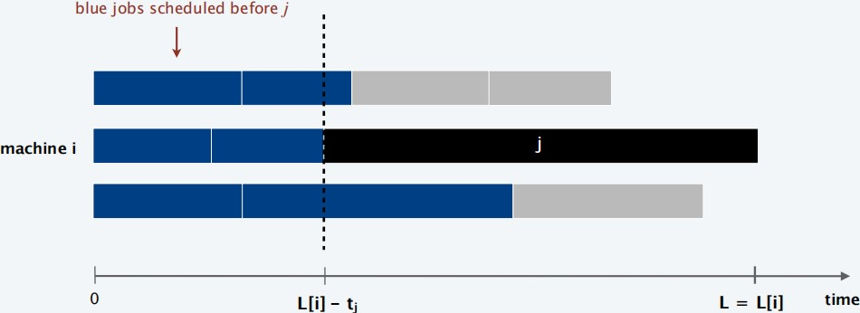

## Greedy for LOAD-BALANCE: analysis

**Theorem**. Greedy algorithm is a 2-approximation.  
**Pf**. Consider load $L[i]$ of *bottleneck* machine $i$.

- Let $j$ be last job scheduled on machine $i$.
- When job $j$ assigned to machine $i$, $i$ had smallest load.
  - Its load before assignment is $L[i] - t_j$; hence $L[i] - t_j \le L[k]$ for all $1 \le k \le m$.
- Sum inequalities over all $k$ and divide by $m$:

$$L[i] - t_j \le \frac{1}{m} \sum_{k} L[k] = \frac{1}{m} \sum_{k} t_k \le L^\ast$$

- Now, $L = L[i] = \underbrace{(L[i] - t_j)}_{\le L^\ast} + \underbrace{t_j}_{\le L^\ast} \le 2 L^\ast$.

## Greedy for LOAD-BALANCE: tightness

**Q**. Is our analysis tight?  
**A**. Essentially yes.

**Ex**: $m$ machines, first $m (m – 1)$ jobs have length 1, last job has length $$m.

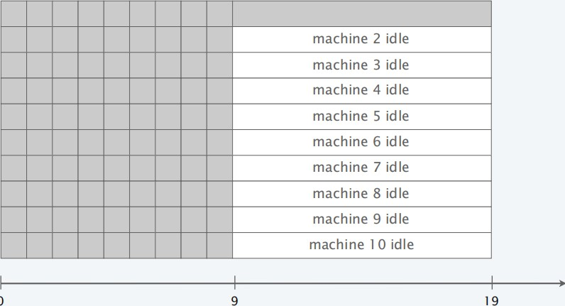

- list scheduling makespan $= 19 = 2m - 1$
- optimal makespan $= 10 = m$

## Load balancing: LPT rule

**Longest processing time (LPT)**. Sort $n$ jobs in *decreasing* order of processing times; then run list scheduling algorithm.

`LPT-LIST-SCHEDULING` ($m, n, t_1, t_2, .., t_n$)

1. SORT jobs and renumber so that $t_1 \ge t_2 \ge .. \ge t_n$.
2. FOR $i = 1 .. m$:
   1. $L[i] = 0$;
   2. $S[i] = \emptyset$;
3. FOR $j = 1 .. n$:
   1. $i = \argmin_k L[k]$;
   2. $S[i] = S[i] \cup \{ j \}$;
   3. $L[i] = L[i] + t_j$;
4. RETURN $S[1], S[2], .., S[m]$;

## LPT for Load balancing: analysis

**Observation**. If bottleneck machine $i$ has only $1$ job, then optimal.  
**Pf**. Any solution must schedule that job.

**Lemma 3**. If there are more than $m$ jobs, $L^\ast \ge 2 t_{m+1}$.  
**Pf**. Consider processing times of first $m+1$ jobs $t_1 \ge t_2 \ge .. \ge t_{m+1}$.

- Each takes at least $t_{m+1}$ time.
- There are $m + 1$ jobs and $m$ machines, so by pigeonhole principle, at least one machine gets two jobs.

**Theorem**. LPT rule is a $3/2$-approximation algorithm.  
**Pf**. [ similar to proof for list scheduling ]

- Consider load $L[i]$ of bottleneck machine $i$.
- Let $j$ be last job scheduled on machine $i$.
  - assuming machine $i$ has at least $2$ jobs, we have $j \ge m + 1$
- Now, $L = L[i] = \underbrace{(L[i] - t_j)}_{\le L^\ast} + \underbrace{t_j}_{\le \frac{1}{2} L^\ast} \le \frac{3}{2} L^\ast$.

## LPT for Load balancing: analysis

**Q**. Is our $3/2$ analysis tight?  
**A**. No.

**Theorem**. [Graham 1969] LPT rule is a $4/3$-approximation.  
**Pf**. More sophisticated analysis of same algorithm.

**Q**. Is Graham’s $4/3$ analysis tight?  
**A**. Essentially yes.

**Ex**.

- $m$ machines, $n = 2m + 1$ jobs
- $2m$ jobs of length $m, m + 1, .., 2m – 1$ and one more job of length $m$.
- Then, $L / L^\ast = ((m + (2m-1)) + m) / (((3m-1)*m+m)/m) = (4m - 1) / (3m)$

# Center selection

## Center selection problem

**Input**. Set of $n$ sites $s_1, .., s_n$ and an integer $k > 0$.

**Center selection problem**. Select set of $k$ centers $C$ so that maximum distance $r(C)$ from a site to nearest center is minimized.

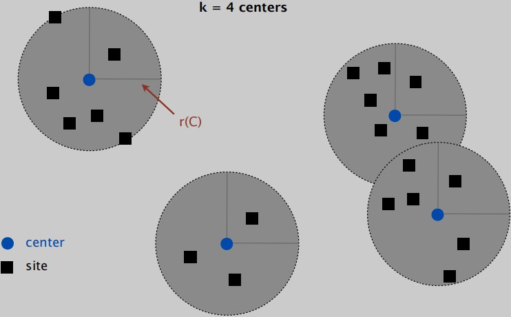

## Center selection problem

**Input**. Set of $n$ sites $s_1, .., s_n$ and an integer $k > 0$.

**Center selection problem**. Select set of $k$ centers $C$ so that maximum distance $r(C)$ from a site to nearest center is minimized.

**Notation**.

- $dist(x, y)$ = distance between sites $x$ and $y$.
- $dist(s_i, C) = \min_{c \in C} dist(s_i, c)$ = distance from $s_i$ to closest center.
- $r(C) = \max_i dist(s_i, C)$ = smallest covering radius.

**Goal**. Find set of centers $C$ that minimizes $r(C)$, subject to $|C| = k$.

**Distance function properties**.

- [ identity ] $dist(x, x) = 0$
- [ symmetry ] $dist(x, y) = dist(y, x)$
- [ triangle inequality ] $dist(x, y) \le dist(x, z) + dist(z, y)$

## Center selection: example

**Ex**: each site is a point in the plane, a center can be any point in the plane, $dist(x, y)$ = Euclidean distance.

**Remark**: search can be infinite!

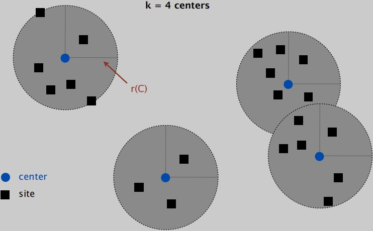

## Greedy algorithm: a false start

**Greedy algorithm**. Put the first center at the best possible location for a single center, and then keep adding centers so as to reduce the covering radius each time by as much as possible.

**Remark**: arbitrarily bad!

- Ex. two seperated cluster of sites.

## Center selection: greedy algorithm

Repeatedly choose next center to be site *farthest* from any existing center.

`GREEDY-CENTER-SELECTION` ($k, n, s_1, s_2, .., s_n$)

1. C = ∅;
2. REPEAT $k$ times
   1. Select a site $s_i$ with maximum distance $dist(s_i, C)$;
   2. $C = C \cup s_i$;
3. RETURN $C$;

**Property**. Upon termination, all centers in $C$ are pairwise at least $r(C)$ apart.  
**Pf**. By construction, $r(C) = \max_i dist(s_i, C)$ = maximum distance $dist(s_i, C)$.

## Greedy for center selection: analysis

**Lemma**. Let $C^\ast$ be an optimal set of centers. Then $r(C) \le 2r(C^\ast)$.  
**Pf**. [by contradiction] Assume $\frac{1}{2} r(C) > r(C^\ast) := r$.

- For each site $c_i \in C$, draw a ball of radius $r$ around it.
- Consider a site $s$ covered by $c_i \in C$, with $dist(s, c_i) > 2r$.
  - $c_i$ covered by $C^\ast$: let $c_i^\ast$ be the center paired with $c_i$.
  - If $s$ covered by $c_i^\ast$, then $dist(s, c_i) > 2r \ge dist(s, c_i^\ast) + dist(c_i^\ast, c_i)$!
  - Otherwise, by farthest selection rule, $dist(s, c_j) > 2r, \forall c_j \in C$.
    - Need $k$ center to cover $c_i \in C$, not possible to cover $s$.

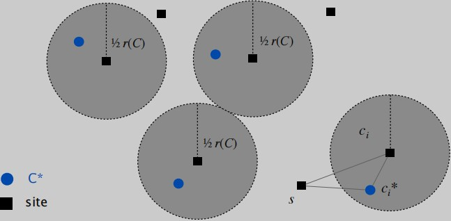

## Center selection

**Lemma**. Let $C^\ast$ be an optimal set of centers. Then $r(C) ≤ 2r (C^\ast)$.

**Theorem**. Greedy algorithm is a 2-approximation for center selection problem.

**Remark**. Greedy algorithm always places centers at sites, but is still within a factor of 2 of best solution that is allowed to place centers anywhere.

**Question**. Is there hope of a $3/2$-approximation? $4/3$?

## DOMINATING-SET $\le_P$ CENTER-SELECTION

**Theorem**. Unless $\mathcal{P} = \mathcal{NP}$, there no $\rho$-approximation for center selection problem for any $\rho < 2$.  
**Pf**. We show how we could use a $(2 – \epsilon)$-approximation algorithm for CENTER-SELECTION selection to solve DOMINATING-SET in poly-time.

**DOMINATING-SET**. Each *vertex* is adjacent to at least one member of the DOMINATING-SET, as opposed to each *edge* being incident to at least one member of the VERTEX-COVER.

## DOMINATING-SET $\le_P$ CENTER-SELECTION

**Theorem**. Unless $\mathcal{P} = \mathcal{NP}$, there no $\rho$-approximation for center selection problem for any $\rho < 2$.  
**Pf**. We show how we could use a $(2 – \epsilon)$-approximation algorithm for CENTER-SELECTION selection to solve DOMINATING-SET in poly-time.

- Let $G = (V, E)$, $k$ be an instance of DOMINATING-SET.
- Construct instance $G'$ of CENTER-SELECTION with sites $V$ and distances
  - $dist(u, v) = 1$ if $(u, v) \in E$
  - $dist(u, v) = 2$ if $(u, v) \notin E$
- Note that $G'$ satisfies the triangle inequality.
- $G$ has dominating set of size $k$ iff there exists $k$ centers $C^\ast$ with $r(C^\ast) = 1$.
- Thus, if $G$ has a dominating set of size $k$, a $(2 – \epsilon)$-approximation algorithm for CENTER-SELECTION would find a solution $C^\ast$ with $r(C^\ast) = 1$ since it cannot use any edge of distance $2$.

# Pricing method: weighted vertex cover

## Weighted vertex cover

**Definition**. Given a graph $G = (V, E)$, a **vertex cover** is a set $S \subseteq V$ such that each edge in $E$ has at least one end in $S$.

**Weighted vertex cover**. Given a graph $G = (V, E)$ with vertex weights $w_i \ge 0$, find a vertex cover of minimum weight.

How to define “progress” in this setting?

- small weight $w_i$.
- cover lots of elements.

## Greedy method

How to define “progress” in this setting?

- small weight $w_i$.
- cover lots of elements.

**Option 1**. $w_i/|S_i|$: “cost per element covered”.

**Option 2**. $w_i/|S_i \cap R|$: we are only concerned with elements still left uncovered.

**Greedy algorithm**. Assignment.

**Greedy analysis**. $O(\log d^\ast)$-approximation, $d^\ast = \max_i |S_i|$. Assignment.

## Pricing method

**Pricing method**. Each edge must be covered by some vertex.  
Edge $e = (i, j)$ pays price $p_e \ge 0$ to use both vertex $i$ and $j$.

**Fairness**. Edges incident to vertex $i$ should pay $\le w_i$ in total.

- ie. $\sum_{e = (i, j)} p_e \le w_i$

**Fairness lemma**. For any vertex cover $S$ and any fair prices $p_e: \sum_e p_e \le w(S)$.  
**Pf**. $\sum_{e \in E} p_e \le \sum_{i \in S} \sum_{e = (i, j)} p_e \le \sum_{i \in S} w_i \le w(S)$.

## Pricing algorithm

`WEIGHTED-VERTEX-COVER` ($G, w$)

1. $S = \emptyset$;
2. FOREACH $e \in E$: $p_e = 0$;
3. WHILE (there exists an edge $(i, j)$ such that neither $i$ nor $j$ is *tight*)
   1. Select such an edge $e = (i, j)$;
   2. Increase $p_e$ as much as possible until $i$ or $j$ tight;
4. $S$ = set of all tight nodes;
5. RETURN $S$;

**tight**. $\sum_{e = (i, j)} p_e = w_i$

## Pricing method: example

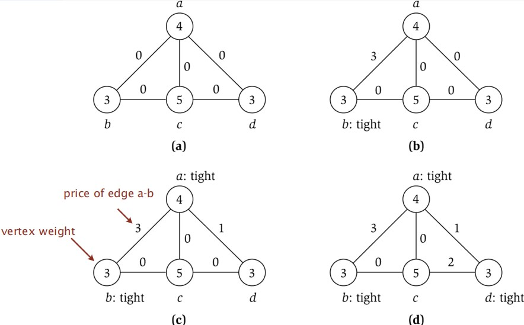

## Pricing method: analysis

**Theorem**. Pricing method is a 2-approximation for WEIGHTED-VERTEX-COVER.  
**Pf**.

- Algorithm terminates since at least one new node becomes tight after each iteration of while loop.
- Let $S$ = set of all tight nodes upon termination of algorithm.
  - $S$ is a vertex cover: if some edge $(i, j)$ is uncovered, then neither $i$ nor $j$ is tight. But then while loop would not terminate.
- Let $S^\ast$ be optimal vertex cover. We show $w(S) ≤ 2 w(S^\ast)$.

$$\begin{aligned}
w(S) & = \sum_{i \in S} w_i & \text{all nodes tight} \\
& = \sum_{i \in S} \sum_{e=(i,j)} p_e & S \subseteq V \\
& \le \sum_{i \in V} \sum_{e=(i,j)} p_e & \text{edge counted twice} \\
& = 2 \sum_{e \in E} pe \le 2 w(S^\ast) & \text{fairness lemma} \\
\end{aligned}$$

# LP rounding: weighted vertex cover

## Weighted vertex cover

**Definition**. Given a graph $G = (V, E)$, a **vertex cover** is a set $S \subseteq V$ such that each edge in $E$ has at least one end in $S$.

**Weighted vertex cover**. Given a graph $G = (V, E)$ with vertex weights $w_i \ge 0$, find a vertex cover of minimum weight.

## Weighted vertex cover: ILP formulation

**Weighted vertex cover**. Given a graph $G = (V, E)$ with vertex weights $w_i \ge 0$, find a vertex cover of minimum weight.

**Integer linear programming formulation**.

- Model inclusion of each vertex $i$ using a $0/1$ variable $x_i$.
  - Vertex covers in 1–1 correspondence with $0/1$ assignments: $S = \{ i \in V : x_i = 1\}$.
- Objective function: minimize $\sum_i w_i x_i$.
- For every edge $(i, j)$, must take either vertex $i$ or $j$ (or both): $x_i + x_j \ge 1$.

## ILP formulation in math language

**Weighted vertex cover**. Integer linear programming formulation.

$$\begin{aligned}
\text{(ILP)}\ & \min & \sum_{i \in V} w_i x_i & & \\
& \text{s.t.} & x_i + x_j & \ge 1 & (i, j) \in E \\
& & x_i & \in \{0, 1\} & i \in V \\
\end{aligned}$$

**Observation**. If $x^\ast$ is optimal solution to ILP, then $S = \{ i \in V : x_i^\ast = 1\}$ is a min-weight vertex cover.

## Integer linear programming

Given integers $a_{ij}, b_i, c_j$, find *integers* $x_j$ that satisfy:

$$\begin{aligned}
\min c^T x & \\
\text{s.t.}\ Ax & \ge b \\
x & \ge 0 \\
x & \ \text{is integral} \\
\end{aligned}$$

$$\begin{aligned}
\min \sum_{j=1}^n c_j x_j & & \\
\text{s.t.}\ \sum_{j=1}^n a_{ij} x_j & \ge b_i & 1 \le i \le m \\
x_j & \ge 0 & 1 \le j \le n \\
x_j & \ \text{is integral} & 1 \le j \le n \\
\end{aligned}$$

**Observation**. Vertex cover formulation proves that INTEGER-PROGRAMMING is an NP-hard optimization problem.

## linear programming

Given integers $a_{ij}, b_i, c_j$, find *real numbers* $x_j$ that satisfy:

$$\begin{aligned}
\min c^T x & \\
\text{s.t.}\ Ax & \ge b \\
x & \ge 0 \\
\end{aligned}$$

$$\begin{aligned}
\min \sum_{j=1}^n c_j x_j & & \\
\text{s.t.}\ \sum_{j=1}^n a_{ij} x_j & \ge b_i & 1 \le i \le m \\
x_j & \ge 0 & 1 \le j \le n \\
\end{aligned}$$

**Linear**. No $x^2, xy, \arccos(x), x (1 – x)$, etc.

**Simplex algorithm**. [Dantzig 1947] Can solve LP in practice.

**Ellipsoid algorithm**. [Khachiyan 1979] Can solve LP in poly-time.

**Interior point algorithms**. [Karmarkar 1984, Renegar 1988, … ] Can solve LP both in poly-time and in practice.

## LP feasible region

**LP geometry in 2D**.

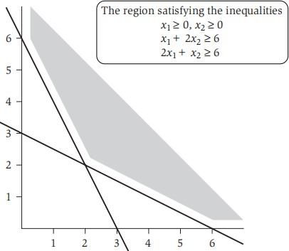

## Weighted vertex cover: LP relaxation

**Linear programming relaxation.**

$$\begin{aligned}
\text{(ILP)}\ & \min & \sum_{i \in V} w_i x_i & & \\
& \text{s.t.} & x_i + x_j & \ge 1 & (i, j) \in E \\
& & x_i & \in \{0, 1\} & i \in V \\
\end{aligned}$$

$$\begin{aligned}
\text{(LP)}\ & \min & \sum_{i \in V} w_i x_i & & \\
& \text{s.t.} & x_i + x_j & \ge 1 & (i, j) \in E \\
& & x_i & \ge 0 & i \in V \\
\end{aligned}$$

**Observation**. Optimal value of LP is $\le$ optimal value of ILP, ie. better.  
**Pf**. LP has fewer constraints.

**Note**. LP solution $x^\ast$ may not correspond to a vertex cover. (even if all weights are 1)

**Q**. How can solving LP help us find a low-weight vertex cover?  
**A**. Solve LP and *round* fractional values in $x^\ast$.

## LP rounding algorithm

**Lemma**. If $x^\ast$ is optimal solution to LP, then $S = { i \in V : x_i^\ast \ge \frac{1}{2} }$ is a vertex cover whose weight is at most twice the min possible weight.  
**Pf**. [ $S$ is a vertex cover ]

- Consider an edge $(i, j) \in E$.
- Since $x_i^\ast + x_j^\ast \ge 1$, either $x_i^\ast \ge \frac{1}{2} or x_j^\ast \ge \frac{1}{2}$ (or both) $\Rightarrow (i, j)$ covered.

**Pf**. [ $S$ has desired weight ]

- Let $S^\ast$ be optimal vertex cover. Then
  - $\sum_{i \in S^\ast} w_i \ge \sum_{i \in S} w_i x_i^\ast \ge \frac{1}{2} \sum_{i \in S} w_i$

**Theorem**. The rounding algorithm is a 2-approximation algorithm.  
**Pf**. Lemma + fact that LP can be solved in poly-time.

## Weighted vertex cover inapproximability

**Theorem**. [Dinur–Safra 2004] If $\mathcal{P} \ne \mathcal{NP}$, then no $\rho$-approximation algorithm for WEIGHTED-VERTEX-COVER for any $\rho < 1.3606$ (even if all weights are 1).

**Open research problem**. Close the gap.

**Theorem**. [Kohot–Regev 2008] If Unique Games Conjecture is true, then no $(2 - \epsilon)$-approximation algorithm for WEIGHTED-VERTEX-COVER for any $\epsilon > 0$.

**Open research problem**. Prove the Unique Games Conjecture.

# Generalized load balancing

## Generalized load balancing

**Input**. Set of $m$ machines $M$; set of $n$ jobs $J$.

- Job $j \in J$ must run contiguously on an *authorized machine* in $M_j \subseteq M$.
- Job $j \in J$ has processing time $t_j$.
- Each machine can process at most one job at a time.

**Def**. Let $J_i$ be the subset of jobs assigned to machine $i$.  
The **load** of machine $i$ is $L_i = \sum_{j \in J_i} t_j$.

**Def**. The **makespan** is the maximum load on any machine = $\max_i L_i$.

**Generalized load balancing**. Assign each job to an authorized machine to minimize makespan.

## Integer linear program and relaxation

**ILP formulation**. $x_{ij}$ = time that machine $i$ spends processing job $j$.

$$\begin{aligned}
\text{(ILP)}\ & \min & L & & \\
& \text{s.t.} & \sum_i x_{ij} & = t_j & \forall j \in J \\
& & \sum_j x_{ij} & \le L & \forall i \in M \\
& & x_{ij} & \in \{0, t_j\} & \forall j \in J, i \in M_j \\
& & x_{ij} & = 0 & \forall j \in J, i \notin M_j \\
\end{aligned}$$

**LP relaxation**.

$$\begin{aligned}
\text{(LP)}\ & \min & L & & \\
& \text{s.t.} & \sum_i x_{ij} & = t_j & \forall j \in J \\
& & \sum_j x_{ij} & \le L & \forall i \in M \\
& & x_{ij} & \ge 0 & \forall j \in J, i \in M_j \\
& & x_{ij} & = 0 & \forall j \in J, i \notin M_j \\
\end{aligned}$$

## Lower bounds

**Lemma 1**. The optimal makespan $L^\ast \ge \max_j t_j$.  
**Pf**. Some machine must process the most time-consuming job.

**Lemma 2**. Let $L$ be optimal value to the LP. Then, optimal makespan $L^\ast \ge L$.  
**Pf**. LP has fewer constraints than ILP formulation.

## Structure of LP solution

**Lemma 3**. Let $x$ be solution to LP. Let $G(x)$ be the graph with an edge between machine $i$ and job $j$ if $x_{ij} > 0$. Then $G(x)$ is *acyclic*.  
**Pf**. (deferred)

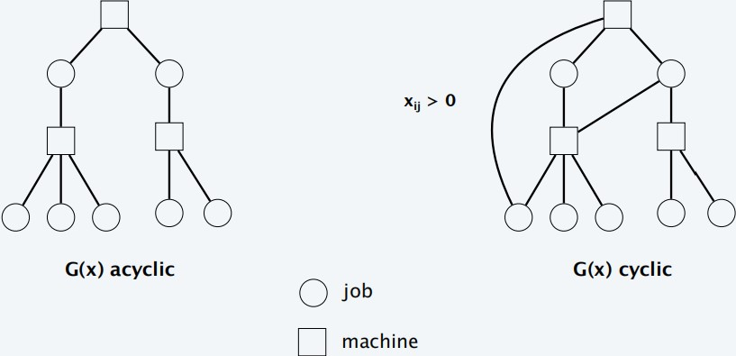

Why a job can connect to multiple machines?

- LP solution may break the job into small fractions.

## Generalized LB: rounding

**Rounded solution**. Find LP solution $x$ where $G(x)$ is a forest. Root forest $G(x)$ at some *arbitrary* machine node $r$.

- If job $j$ is a leaf node, assign $j$ to its parent machine i.
- If job $j$ is not a leaf node, assign $j$ to *any* one of its children.

**Lemma 4**. Rounded solution only assigns jobs to authorized machines.  
**Pf**. If job $j$ is assigned to machine $i$, then $x_{ij} > 0$. LP solution can only assign positive value to authorized machines.

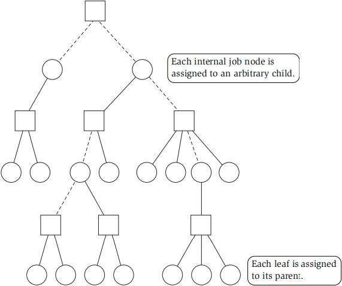

## Generalized LB: analysis

**Lemma 5**. If job $j$ is a leaf node and machine $i = parent(j)$, then $x_{ij} = t_j$.  
**Pf**.

- Since $j$ is a leaf, $x_{ij} = 0$ for all $k \ne parent(j)$.
- LP constraint guarantees $\sum_i x_{ij} = t_j$.

**Lemma 6**. At most one non-leaf job is assigned to a machine.  
**Pf**. The only possible non-leaf job assigned to machine $i$ is $parent(i)$.

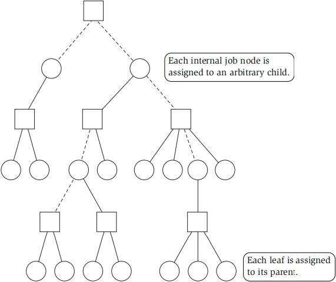

## Generalized LB: analysis

**Theorem**. Rounded solution is a $2$-approximation.  
**Pf**.

- Let $J(i)$ be the jobs assigned to machine $i$.
- By LEMMA 6, the load $L_i$ on machine $i$ has two components:
  - parent: $t_{parent(i)} \le L^\ast$ (LEMMA 1)
  - leaf nodes:

$$\begin{aligned}
\sum_{j \in J(i)} t_j & = \sum_{j \in J(i)} x_{ij} & \text{LEMMA 5} \\
& \le \sum_{j \in J} x_{ij} \le L & \text{LP} \\
& \le L^\ast & \text{LEMMA 2} \\
\end{aligned}$$

- Thus, the overall load $L_i \le 2 L^\ast$.

## Generalized LB: flow formulation

**Flow formulation of LP**.

$$\begin{aligned}
\sum_i x_{ij} & = t_j & \forall j \in J \\
\sum_j x_{ij} & \le L & \forall i \in M \\
x_{ij} & \ge 0 & \forall j \in J, i \in M_j \\
x_{ij} & = 0 & \forall j \in J, i \notin M_j \\
\end{aligned}$$

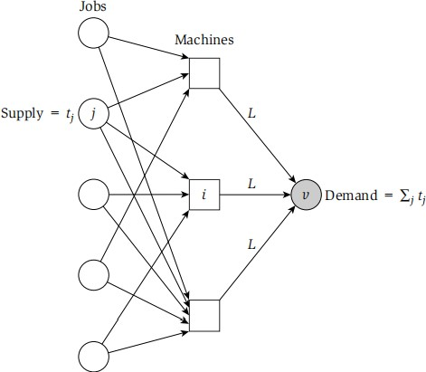

**Observation**. Solution to feasible flow problem with value $L$ are in 1-to-1 correspondence with LP solutions of value $L$.

## Generalized LB: structure of solution

**Lemma 3**. Let $(x, L)$ be solution to LP. Let $G(x)$ be the graph with an edge from machine $i$ to job $j$ if $x_{ij} > 0$. We can find another solution $(x', L)$ such that $G(x')$ is acyclic.  
**Pf**. Let $C$ be a cycle in $G(x)$.

- Augment flow along the cycle $C$ (maintain conservation).
- At least one edge from $C$ is removed (and none are added).
- Repeat until $G(x')$ is acyclic.

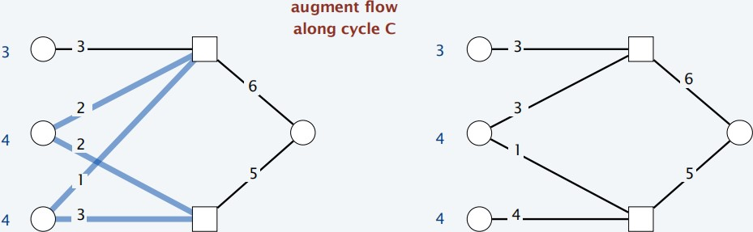

## Conclusions

**Running time**. The bottleneck operation in our 2-approximation is solving one LP with $m n + 1$ variables.

**Remark**. Can solve LP using flow techniques on a graph with $m + n + 1$ nodes:  
given $L$, find feasible flow if it exists. Binary search to find $L^\ast$.

**Extensions**: unrelated parallel machines. [Lenstra–Shmoys–Tardos 1990]

- Job $j$ takes $t_{ij}$ time if processed on machine $i$.
- $2$-approximation algorithm via LP rounding.
- If $\mathcal{P} \ne \mathcal{NP}$, then no no $\rho$-approximation exists for any $\rho < 3/2$.

# Knapsack problem

## Polynomial-time approximation scheme

**PTAS**. $(1 + \epsilon)$-approximation algorithm for any constant $\epsilon > 0$.

- Load balancing. [Hochbaum–Shmoys 1987]
- Euclidean TSP. [Arora, Mitchell 1996]

**Consequence**. PTAS produces arbitrarily high quality solution, but trades off accuracy for time.

**This section**. PTAS for knapsack problem via rounding and scaling.

## Knapsack problem

**Knapsack problem**.

- Given $n$ objects and a knapsack.
- Item $i$ has value $v_i > 0$ and weighs $w_i > 0$.
- Knapsack has *weight limit* $W$.
- Goal: fill knapsack so as to *maximize total value*.

**Ex**: $\{ 3, 4 \}$ has value $40$.

| item | value | weight |
| --- | --- | --- |
| 1 | 1 | 1 |
| 2 | 6 | 2 |
| 3 | 18 | 5 |
| 4 | 22 | 6 |
| 5 | 28 | 7 |

## Knapsack is NP-complete

**SUBSET-SUM**. Given a set $X$, values $u_i ≥ 0$, and an integer $U$, is there a subset $S \subseteq X$ whose elements sum to exactly $U$?

## Knapsack problem: DP I

**Def**. $OPT(i, w)$ = max value subset of items $1, .., i$ with *weight* limit $w$.

**Case 1**. $OPT$ does not select item $i$.

- $OPT$ selects best of $1, .., i - 1$ using up to weight limit $w$.

**Case 2**. $OPT$ selects item $i$.

- New weight limit = $w - w_i$.
- $OPT$ selects best of $1, .., i - 1$ using up to weight limit $w - w_i$.

$$OPT(i, w) = \left\{ \begin{array}{ll}
0 & \text{if}\ i = 0 \\
OPT(i-1, w) & \text{if}\ w_i > w \\
\max \{ OPT(i-1, w), v_i + OPT(i-1, w-w_i) \} & \text{otherwise} \\
\end{array}\right.$$

**Theorem**. Computes the optimal value in $O(n W)$ time.

- Not polynomial in input size.
- Polynomial in input size if weights are small integers.

## Knapsack problem: DP II

**Def**. $OPT(i, v)$ = min weight of a knapsack for which we can obtain a solution of *value* $\ge v$ using a subset of items $1, .., i$.

**Note**. Optimal value is the largest value $v$ such that $OPT(n, v) \le W$.

**Case 1**. $OPT$ does not select item $i$.

- $OPT$ selects best of $1, .., i - 1$ that achieves value $\ge v$.

**Case 2**. $OPT$ selects item $i$.

- Consumes weight $w_i$, need to achieve value $\ge v - v_i$.
- $OPT$ selects best of $1, .., i - 1$ that achieves value $\ge v - v_i$.

$$OPT(i, v) = \left\{ \begin{array}{ll}
0 & \text{if}\ v \le 0 \\
\infty & \text{if}\ i = 0\ \text{and}\ v > 0 \\
\min \{ OPT(i-1, v), w_i + OPT(i-1, v-v_i) \} & \text{otherwise} \\
\end{array}\right.$$

## Knapsack problem: DP II (cont.)

**Theorem**. Dynamic programming algorithm II computes the optimal value in $O(n^2 v_{max})$ time, where $v_{max}$ is the maximum of any value.  
**Pf**.

**Remark 1**. Not polynomial in input size! (pseudo-polynomial)  
**Remark 2**. Polynomial time if values are small integers.

## Poly-time approximation scheme

**Intuition for approximation algorithm**.

- Round all values up to lie in smaller range.
- Run dynamic programming algorithm II on rounded/scaled instance.
- Return optimal items in rounded instance.

| item | value | weight |
| --- | --- | --- |
| 1 | 934221 | 1 |
| 2 | 5956342 | 2 |
| 3 | 17810013 | 5 |
| 4 | 21217800 | 6 |
| 5 | 27343199 | 7 |

| item | value | weight |
| --- | --- | --- |
| 1 | 1 | 1 |
| 2 | 6 | 2 |
| 3 | 18 | 5 |
| 4 | 22 | 6 |
| 5 | 28 | 7 |

## Poly-time approximation scheme

**Round up all values**:

- $0 < \epsilon \le 1$ = precision parameter.
- $v_{max}$ = largest value in original instance.
- $\theta$ = scaling factor = $\epsilon v_{max} / 2n$.

$$\bar{v_i} = \lceil \frac{v_i}{\theta} \rceil \theta,
\hat{v_i} = \lceil \frac{v_i}{\theta} \rceil$$

**Observation**. Optimal solutions to problem with $\bar{v}$ are equivalent to optimal solutions to problem with $\hat{v}$.

**Intuition**. $\bar{v}$ close to $v$ so optimal solution using $\bar{v}$ is nearly optimal; $\hat{v}$ small and integral so dynamic programming algorithm II is fast.

## Poly-time approximation scheme

**Theorem**. If $S$ is solution found by rounding algorithm and $S^\ast$ is any other feasible solution satisfying weight constraint, then $(1 + \epsilon) \sum_{i \in S} v_i \ge \sum_{i \in S^\ast} v_i$  
**Pf**.

$$\begin{aligned}
\sum_{i \in S^\ast} v_i & \le \sum_{i \in S^\ast} \bar{v_i} && \text{round up}\\
& \le \sum_{i \in S} \bar{v_i} && \text{optimality} \\
& \le \sum_{i \in S} (v_i + \theta) && \text{rounding gap} \\
& \le \sum_{i \in S} v_i + n\theta && |S| \le n \\
& = \sum_{i \in S} v_i + \frac{1}{2} \epsilon v_{max} && \theta = \epsilon v_{max} / 2n \\
& \le (1 + \epsilon) \sum_{i \in S} v_i && v_{max} \le 2 \sum_{i \in S} v_i \\
\end{aligned}$$

## Poly-time approximation scheme

**Theorem**. For any $\epsilon > 0$, the rounding algorithm computes a feasible solution whose value is within a $(1 + \epsilon)$ factor of the optimum in $O(n^3 / \epsilon)$ time.  
**Pf**.

- We have already proved the accuracy bound.
- Dynamic program II running time is $O(n^2 \hat{v}_{max})$, where

$$\hat{v}_{max} = \lceil \frac{v_{max}}{\theta} \rceil = \lceil \frac{2n}{\epsilon} \rceil$$